# hw1

## HW1

- This homework aims to validate Abadie et al (2018) using simulated dataset

### Background

- Abadie et al (2018) argue over-fitting is manifest when researchers divide recipients into different groups to investigate potential heterogeneity in RCT, and propose possible estimators to alleviate such bias. Specifically,
- Findings
  - Over-fitting appears in ATE when stratification is based on recipients own characteristics.
  - In high score group, ATE is underestimated, whereas ATE is overestimated in low score group.
  - Famous JTPA and STAR experiments both incur ATE bias described above.
  - Using leave-one-out or repeated split sample estimators can address over-fitting and obtain consistent coefficients.

### Methodology

- We generate random sample following Normal distribution with 10,000 simulations and randomly group them into control and treatment groups
- In our DGP, samples are randomly selected into treatment group and control group, hence, ATE estimator is supposed to be indistinguishable from 0
- Specifically, we consider small sample properties and large sample properties in our simulations

### Results

- Figure 1 presents small sample ATE estimates stratified by score of covariates, it manifests that
  - Low score group has an overestimated tendency (+7.8)
  - High score group has an underestimated tendency (-7.2)
  - These deviations are about 700% of mean of y
- Figure 2 presents small sample repeated split sample ATE estimates stratified by score of covariates, the pattern of underestimation and overestimation is almost indistinguishable.
- Figure 3 and 4 present large sample ATE estimates based on overall sample and repeated split sample estimators, respectively. In large sample, the bias we find in small sample case is greatly alleviated.
  - In Figure 3. Low score group tends to overestimate ATE, and high score group tends to underestimate ATE, whereas the magnitude is almost indistinguishable.
  - In Figure 4. None of groups tends to biase, similar with Figure 2.
- Overall. repeated split sample estimator can greatly alleviate the ATE bias induced by endogenous stratification regardless of small of large samples.

### Reference

Abadie, A., Chingos, M. M., and West, M. R. (2018). Endogenous stratification in randomized experiments. Review of Economics and Statistics, 100(4), 567-580.

```python
# Function: HW1
# Writer: Mingyi Li
# Date: 2022/04/14
```

```python
import numpy as np
import pandas as pd
import sklearn
import random
from sklearn.linear_model import LinearRegression
from sklearn.model_selection import train_test_split
import seaborn as sns
import matplotlib.pyplot as plt
%matplotlib inline
```

```python
columns = []
for i in range(40):
    columns.append('x'+str(i))
```

```python
# empty lists to store ATEs
low_bs = []
mid_bs = []
high_bs = []
```

```python
# We run 10,000 simulations with 100 samples to show small sample properties of baseline estimate
for epoch in range(10000):
    # Features:(100,40). i.i.d. Standard Normal
    X = np.random.normal(loc=0, scale= 1,size=(100,40))
    # True coefficients, all betas = 1
    b = np.ones(40)
    # Error, Normal(0,60)
    e = np.random.normal(loc=0, scale= np.sqrt(60), size = (100,1))
    # By Normal additivity, y follows Normal(1, 100)
    y = 1 + np.expand_dims(X.dot(b),axis=1) + e
    X = pd.DataFrame(X, columns=columns)
    y = pd.DataFrame(y, columns=['y'])
    # Randomly divide total sample into Control group (training group) and Treat Group (Test group)
    X_train,X_test = X.iloc[:50,:],X.iloc[50:,:]
    y_train,y_test = y.iloc[:50,:],y.iloc[50:,:]

    # We use all relevant Xs to estimate and it is readily to use other numbers of features here.
    # Use all training sample to estimate our linear model
    model40 = LinearRegression()
    model40.fit(X_train, y_train)

    y_train_pred = model40.predict(X_train)
    # X_res stores all features and estimated y
    # y_res stores real y and estimated y
    # Estimated y is employed as a sorting variable
    X_res = pd.concat([X_train,pd.DataFrame(y_train_pred,columns=['y_pred'])],axis=1)
    y_res = pd.concat([y_train,pd.DataFrame(y_train_pred,columns=['y_pred'])],axis=1)
    y_res = y_res.sort_values(by='y_pred')


    # Predict y in test sample
    y_test_pred = pd.DataFrame(model40.predict(X_test),columns=['y_pred'])
    # Similarly, concatenate estimated y in test group
    X_test_res = pd.DataFrame(np.concatenate((X_test,y_test_pred),axis=1),columns=X_res.columns)
    y_test_res = pd.DataFrame(np.concatenate((y_test,y_test_pred),axis=1),columns=y_res.columns)
    y_test_res = y_test_res.sort_values(by='y_pred')

    # We use predicted value using all available features to sort observations into three equally spiltted groups
    # based on their estimated y, and appending estimated ATE in corresponding lists
    low_bs.append(y_test_res.iloc[:16,:].mean()[0] - y_res.iloc[:16,:].mean()[0])
    mid_bs.append(y_test_res.iloc[16: 16 * 2,:].mean()[0] - y_res.iloc[16: 16 * 2,:].mean()[0])
    high_bs.append(y_test_res.iloc[16*2:,:].mean()[0] - y_res.iloc[16*2:,:].mean()[0])
```

```
Mean Estimated Artificial Treatment Effect in LOW Group 7.796453762410331
----------------------------------------------------
Mean Estimated Artificial Treatment Effect in MIDDLE Group 0.3544203034813936
----------------------------------------------------
Mean Estimated Artificial Treatment Effect in HIGH Group -7.21926878522942
----------------------------------------------------
```

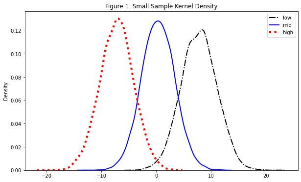

```python
print('Mean Estimated Artificial Treatment Effect in LOW Group ' + str(np.mean(low_bs)))
print('----------------------------------------------------')
print('Mean Estimated Artificial Treatment Effect in MIDDLE Group ' + str(np.mean(mid_bs)))
print('----------------------------------------------------')
print('Mean Estimated Artificial Treatment Effect in HIGH Group ' + str(np.mean(high_bs)))
print('----------------------------------------------------')


# We present ATE distributions below with kernel density plots
fig, axes = plt.subplots(figsize=(10,6))
sns.kdeplot(low_bs, legend='low', color='k', linewidth='2', linestyle='-.');
sns.kdeplot(mid_bs, legend='mid', color='b', linewidth='2', linestyle='-');
sns.kdeplot(high_bs, legend='high', color='r', linewidth='4', linestyle=':');
plt.legend(['low','mid','high']);
axes.set_title('Figure 1. Small Sample Kernel Density');
```

```python
# empty lists to store ATEs
low_s = []
mid_s = []
high_s = []
```

```python
# Furthermore, we attempt to investigate small sample properties of repeated split sample estimate
# we consider 100 samples with 10,000 simulations
for epoch in range(10000):
    # DGP is identical with our baseline
    X = np.random.normal(loc=0, scale= 1,size=(100,40))
    b = np.ones(40)
    e = np.random.normal(loc=0, scale= np.sqrt(60), size = (100,1))
    y = 1 + np.expand_dims(X.dot(b),axis=1) + e
    X = pd.DataFrame(X, columns=columns)
    y = pd.DataFrame(y, columns=['y'])
    X_train,X_test = X.iloc[:50,:],X.iloc[50:,:]
    y_train,y_test = y.iloc[:50,:],y.iloc[50:,:]
    # In each repetition, we repeatedly split training dataset 100 times,
    # and we generate temporary variables to store estimated ATE in each split
    temp_low = []
    temp_mid = []
    temp_high = []
    for i in range(100):
        # Training set is equally divided into estimation set and prediction set, where the former is to estimate betas
        # and the latter is for estimating ATE
        X_train_est,X_train_pre,y_train_est,y_train_pre = train_test_split(X_train,y_train, train_size=0.5)
        model40 = LinearRegression()
        model40.fit(X_train_est, y_train_est)
        y_train_pred = model40.predict(X_train_pre)
        X_res = pd.DataFrame(np.concatenate([X_train_pre,y_train_pred],axis=1), columns=X_res_cols)
        y_res = pd.DataFrame(np.concatenate([y_train_pre,y_train_pred],axis=1), columns=['y','y_pred'])
        y_res = y_res.sort_values(by='y_pred')
        y_test_pred = pd.DataFrame(model40.predict(X_test),columns=['y_pred'])

        X_test_res = pd.DataFrame(np.concatenate((X_test,y_test_pred),axis=1),columns=X_res.columns)
        y_test_res = pd.DataFrame(np.concatenate((y_test,y_test_pred),axis=1),columns=y_res.columns)
        y_test_res = y_test_res.sort_values(by='y_pred')


        temp_low.append(y_test_res.iloc[:16,:].mean()[0] - y_res.iloc[:8,:].mean()[0])
        temp_mid.append(y_test_res.iloc[16: 16 * 2,:].mean()[0] - y_res.iloc[8: 8 * 2,:].mean()[0])
        temp_high.append(y_test_res.iloc[16*2:,:].mean()[0] - y_res.iloc[8*2:,:].mean()[0])

    # Store the mean of estimated ATE in each training set split
    low_s.append(np.mean(temp_low))
    mid_s.append(np.mean(temp_mid))
    high_s.append(np.mean(temp_high))
```

```
Mean Estimated Artificial Treatment Effect in LOW Group -0.06618091482650873
----------------------------------------------------
Mean Estimated Artificial Treatment Effect in MIDDLE Group -0.015243226361924274
----------------------------------------------------
Mean Estimated Artificial Treatment Effect in HIGH Group 0.014267856530450396
----------------------------------------------------
```

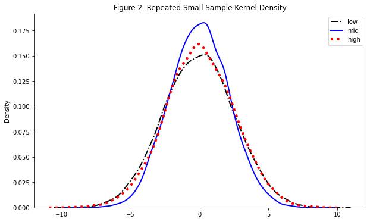

```python
print('Mean Estimated Artificial Treatment Effect in LOW Group ' + str(np.mean(low_s)))
print('----------------------------------------------------')
print('Mean Estimated Artificial Treatment Effect in MIDDLE Group ' + str(np.mean(mid_s)))
print('----------------------------------------------------')
print('Mean Estimated Artificial Treatment Effect in HIGH Group ' + str(np.mean(high_s)))
print('----------------------------------------------------')


# We present ATE distributions below with kernel density plots
fig, axes = plt.subplots(figsize=(10,6))
sns.kdeplot(low_s, legend='low', color='k', linewidth='2', linestyle='-.');
sns.kdeplot(mid_s, legend='mid', color='b', linewidth='2', linestyle='-');
sns.kdeplot(high_s, legend='high', color='r', linewidth='4', linestyle=':');
plt.legend(['low','mid','high']);
axes.set_title('Figure 2. Repeated Small Sample Kernel Density');
```

```python
# Empty lists to store estimators
low = []
mid = []
high = []
```

```python
# We run 10,000 times in our simulation, and it is readily to change to other numbers of repetitions
# This block is our baseline estimate
for epoch in range(10000):
    # Features:(10000,40). i.i.d. Standard Normal
    X = np.random.normal(loc=0, scale= 1,size=(10000,40))
    # True coefficients, all betas = 1
    b = np.ones(40)
    # Error, Normal(0,60)
    e = np.random.normal(loc=0, scale= np.sqrt(60), size = (10000,1))
    # By Normal additivity, y follows Normal(1, 100)
    y = 1 + np.expand_dims(X.dot(b),axis=1) + e
    X = pd.DataFrame(X, columns=columns)
    y = pd.DataFrame(y, columns=['y'])
    # Randomly divide total sample into Control group (training group) and Treat Group (Test group)
    X_train,X_test = X.iloc[:5000,:],X.iloc[5000:,:]
    y_train,y_test = y.iloc[:5000,:],y.iloc[5000:,:]

    # We use all relevant Xs to estimate and it is readily to use other numbers of features here.
    # Use all training sample to estimate our linear model
    model40 = LinearRegression()
    model40.fit(X_train, y_train)

    y_train_pred = model40.predict(X_train)
    # X_res stores all features and estimated y
    # y_res stores real y and estimated y
    # Estimated y is employed as a sorting variable
    X_res = pd.concat([X_train,pd.DataFrame(y_train_pred,columns=['y_pred'])],axis=1)
    y_res = pd.concat([y_train,pd.DataFrame(y_train_pred,columns=['y_pred'])],axis=1)
    y_res = y_res.sort_values(by='y_pred')


    # Predict y in test sample
    y_test_pred = pd.DataFrame(model40.predict(X_test),columns=['y_pred'])
    # Similarly, concatenate estimated y in test group
    X_test_res = pd.DataFrame(np.concatenate((X_test,y_test_pred),axis=1),columns=X_res.columns)
    y_test_res = pd.DataFrame(np.concatenate((y_test,y_test_pred),axis=1),columns=y_res.columns)
    y_test_res = y_test_res.sort_values(by='y_pred')

    # We use predicted value using all available features to sort observations into three equally spiltted groups
    # based on their estimated y, and appending estimated ATE in corresponding lists
    low.append(y_test_res.iloc[:1667,:].mean()[0] - y_res.iloc[:1667,:].mean()[0])
    mid.append(y_test_res.iloc[1667: 1666 * 2,:].mean()[0] - y_res.iloc[1667: 1666 * 2,:].mean()[0])
    high.append(y_test_res.iloc[1666*2:,:].mean()[0] - y_res.iloc[1666*2:,:].mean()[0])
```

```
Mean Estimated Artificial Treatment Effect in LOW Group 0.07781369651361496

5% Estimated Artificial Treatment Effect in LOW Group -0.4324338047942718

95% Estimated Artificial Treatment Effect in LOW Group 0.6056602133954908
----------------------------------------------------
Mean Estimated Artificial Treatment Effect in MIDDLE Group -0.0018599899115522064

5% Estimated Artificial Treatment Effect in MIDDLE Group -0.5046455856712554

95% Estimated Artificial Treatment Effect in MIDDLE Group 0.48701559647635845
----------------------------------------------------
Mean Estimated Artificial Treatment Effect in HIGH Group -0.0827736786538444

5% Estimated Artificial Treatment Effect in HIGH Group -0.5973922071431377

95% Estimated Artificial Treatment Effect in HIGH Group 0.43019964559140644
----------------------------------------------------
```

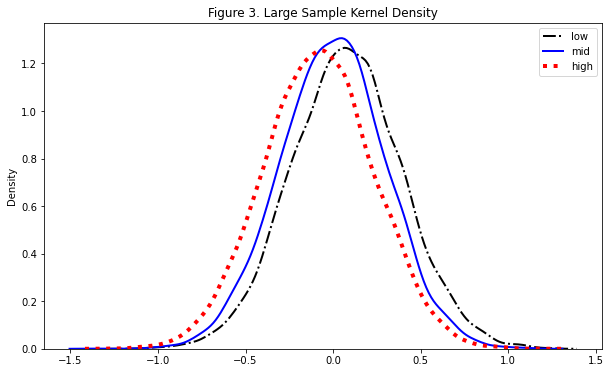

```python
print('Mean Estimated Artificial Treatment Effect in LOW Group ' + str(np.mean(low)))
print()
print('5% Estimated Artificial Treatment Effect in LOW Group ' + str(np.quantile(low,0.05)))
print()
print('95% Estimated Artificial Treatment Effect in LOW Group ' + str(np.quantile(low,0.95)))
print('----------------------------------------------------')


print('Mean Estimated Artificial Treatment Effect in MIDDLE Group ' + str(np.mean(mid)))
print()
print('5% Estimated Artificial Treatment Effect in MIDDLE Group ' + str(np.quantile(mid,0.05)))
print()
print('95% Estimated Artificial Treatment Effect in MIDDLE Group ' + str(np.quantile(mid,0.95)))
print('----------------------------------------------------')


print('Mean Estimated Artificial Treatment Effect in HIGH Group ' + str(np.mean(high)))
print()
print('5% Estimated Artificial Treatment Effect in HIGH Group ' + str(np.quantile(high,0.05)))
print()
print('95% Estimated Artificial Treatment Effect in HIGH Group ' + str(np.quantile(high,0.95)))
print('----------------------------------------------------')


# We present ATE distributions below with kernel density plots
fig, axes = plt.subplots(figsize=(10,6))
sns.kdeplot(low, legend='low', color='k', linewidth='2', linestyle='-.');
sns.kdeplot(mid, legend='mid', color='b', linewidth='2', linestyle='-');
sns.kdeplot(high, legend='high', color='r', linewidth='4', linestyle=':');
plt.legend(['low','mid','high']);
axes.set_title('Figure 3. Large Sample Kernel Density');
```

```python
# Column names we will use in this part
X_res_cols = columns[:]
X_res_cols.append( 'y_pred')
```

```python
# empty lists to store ATEs
low_r = []
mid_r = []
high_r = []
```

```python
# Similarly, we consider 10,000 repetitions
# This block employs repeated split sample estimate
for epoch in range(700):
    # DGP is identical with our baseline
    X = np.random.normal(loc=0, scale= 1,size=(10000,40))
    b = np.ones(40)
    e = np.random.normal(loc=0, scale= np.sqrt(60), size = (10000,1))
    y = 1 + np.expand_dims(X.dot(b),axis=1) + e
    X = pd.DataFrame(X, columns=columns)
    y = pd.DataFrame(y, columns=['y'])
    X_train,X_test = X.iloc[:5000,:],X.iloc[5000:,:]
    y_train,y_test = y.iloc[:5000,:],y.iloc[5000:,:]
    # In each repetition, we repeatedly split training dataset 100 times,
    # and we generate temporary variables to store estimated ATE in each split
    temp_low = []
    temp_mid = []
    temp_high = []
    for i in range(100):
        # Training set is equally divided into estimation set and prediction set, where the former is to estimate betas
        # and the latter is for estimating ATE
        X_train_est,X_train_pre,y_train_est,y_train_pre = train_test_split(X_train,y_train, train_size=0.5)
        model40 = LinearRegression()
        model40.fit(X_train_est, y_train_est)
        y_train_pred = model40.predict(X_train_pre)
        X_res = pd.DataFrame(np.concatenate([X_train_pre,y_train_pred],axis=1), columns=X_res_cols)
        y_res = pd.DataFrame(np.concatenate([y_train_pre,y_train_pred],axis=1), columns=['y','y_pred'])
        y_res = y_res.sort_values(by='y_pred')
        y_test_pred = pd.DataFrame(model40.predict(X_test),columns=['y_pred'])

        X_test_res = pd.DataFrame(np.concatenate((X_test,y_test_pred),axis=1),columns=X_res.columns)
        y_test_res = pd.DataFrame(np.concatenate((y_test,y_test_pred),axis=1),columns=y_res.columns)
        y_test_res = y_test_res.sort_values(by='y_pred')


        temp_low.append(y_test_res.iloc[:1667,:].mean()[0] - y_res.iloc[:833,:].mean()[0])
        temp_mid.append(y_test_res.iloc[1667: 1666 * 2,:].mean()[0] - y_res.iloc[833: 833 * 2,:].mean()[0])
        temp_high.append(y_test_res.iloc[1666*2:,:].mean()[0] - y_res.iloc[833*2:,:].mean()[0])

    # Store the mean of estimated ATE in each training set split
    low_r.append(np.mean(temp_low))
    mid_r.append(np.mean(temp_mid))
    high_r.append(np.mean(temp_high))
```

```python
# Since training takes too long time, we reserve the results in pickles
pd.Series(low_r).to_pickle('low_r')
```

```python
pd.Series(mid_r).to_pickle('mid_r')
```

```python
pd.Series(high_r).to_pickle('high_r')
```

```
Mean Estimated Artificial Treatment Effect in LOW Group -0.0015451034379930714

5% Estimated Artificial Treatment Effect in LOW Group -0.5072695221247575

95% Estimated Artificial Treatment Effect in LOW Group 0.5120574189606375
----------------------------------------------------
Mean Estimated Artificial Treatment Effect in MIDDLE Group -4.15109897562278e-05

5% Estimated Artificial Treatment Effect in MIDDLE Group -0.47642569352645336

95% Estimated Artificial Treatment Effect in MIDDLE Group 0.47535974269201187
----------------------------------------------------
Mean Estimated Artificial Treatment Effect in HIGH Group -0.001436089538990641

5% Estimated Artificial Treatment Effect in HIGH Group -0.5063653014244971

95% Estimated Artificial Treatment Effect in HIGH Group 0.5055975932522568
----------------------------------------------------
```

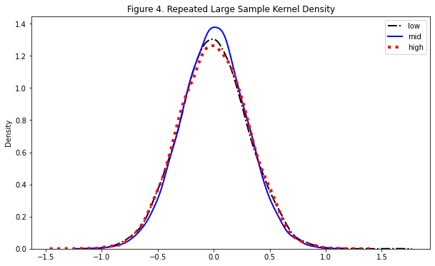

```python
print('Mean Estimated Artificial Treatment Effect in LOW Group ' + str(np.mean(low_r)))
print()
print('5% Estimated Artificial Treatment Effect in LOW Group ' + str(np.quantile(low_r,0.05)))
print()
print('95% Estimated Artificial Treatment Effect in LOW Group ' + str(np.quantile(low_r,0.95)))
print('----------------------------------------------------')


print('Mean Estimated Artificial Treatment Effect in MIDDLE Group ' + str(np.mean(mid_r)))
print()
print('5% Estimated Artificial Treatment Effect in MIDDLE Group ' + str(np.quantile(mid_r,0.05)))
print()
print('95% Estimated Artificial Treatment Effect in MIDDLE Group ' + str(np.quantile(mid_r,0.95)))
print('----------------------------------------------------')


print('Mean Estimated Artificial Treatment Effect in HIGH Group ' + str(np.mean(high_r)))
print()
print('5% Estimated Artificial Treatment Effect in HIGH Group ' + str(np.quantile(high_r,0.05)))
print()
print('95% Estimated Artificial Treatment Effect in HIGH Group ' + str(np.quantile(high_r,0.95)))
print('----------------------------------------------------')


# We present ATE distributions below with kernel density plots
fig, axes = plt.subplots(figsize=(10,6))
sns.kdeplot(low_r, legend='low', color='k', linewidth='2', linestyle='-.');
sns.kdeplot(mid_r, legend='mid', color='b', linewidth='2', linestyle='-');
sns.kdeplot(high_r, legend='high', color='r', linewidth='4', linestyle=':');
plt.legend(['low','mid','high']);
axes.set_title('Figure 4. Repeated Large Sample Kernel Density');
```